# NOAA Storm Database Analisys - Reproducible Research Peer Assessment 2

Daniel Resende

21 de agosto de 2015

## Synopsis

This report explores U.S. National Oceanic and Atmospheric Administration’s (NOAA) storm database, which tracks characteristics of major storm and wheather events in the United States, to trace the social and economic impacts of those events.

```r
if(!("knitr" %in% installed.packages())){
  install.packages("knitr")
}
library(knitr)
if(!("dplyr" %in% installed.packages())){
  install.packages("dplyr")
}
library(dplyr)
if(!("plyr" %in% installed.packages())){
  install.packages("plyr")
}
library(plyr)
if(!("lubridate" %in% installed.packages())){
  install.packages("lubridate")
}
library(lubridate)
if(!("ggplot2" %in% installed.packages())){
  install.packages("ggplot2")
}
library(ggplot2)
if(!("gridExtra" %in% installed.packages())){
  install.packages("gridExtra")
}
library(gridExtra)
```

## Data Processing

The data will be downloaded directly from the source and processed here. No preprocess was done to the data.

```r
if(!file.exists("stormData.bz2")){
  file.url <- "https://d396qusza40orc.cloudfront.net/repdata%2Fdata%2FStormData.csv.bz2"
  download.file(file.url, "stormData.bz2", method = "curl")
  dateDownloaded <- date()
}
storm.data <- read.csv("stormData.bz2")
colnames(storm.data) <- tolower(colnames(storm.data))
```

### Adjusting the Event Type data.

Due to lots of diferent classifications of events and typos found in the data, it’s necessary to process the Event Type data (EVTYPE) to better visualization.

First the event names were all standardized to upper case, any punctuation was replaced by space, leading and trailing spaces were removed and double spaces were changed to single spaces.

```r
levels(storm.data$evtype) <- toupper(levels(storm.data$evtype))
levels(storm.data$evtype) <- gsub("([[:punct:]])|\\s+"," ", levels(storm.data$evtype))
levels(storm.data$evtype) <- gsub("^\\s+|\\s+$", "", levels(storm.data$evtype))
levels(storm.data$evtype) <- gsub("  ", " ", levels(storm.data$evtype))
```

Then the event name were clustered to group toghether diferent classifications of the same event and correct the typos found in the data.

```r
types <- levels(storm.data$evtype)
old.types <- types

#typos
types[grep("AVALANCE", types)] <- "AVALANCHE"
types[grep("BEACH EROSIN", types)] <- "BEACH EROSION"
types[grep("COASTALSTORM", types)] <- "COASTAL STORM"
types[grep("FLASH FLOOODING", types)] <- "FLASH FLOOD"
types[grep("LIGHTING", types)] <- "LIGHTNING"
types[grep("LIGNTNING", types)] <- "LIGHTNING"
types[grep("TORNDAO", types)] <- "TORNADO"
types[grep("BRUSH FIRES", types)] <- "BRUSH FIRE"
types[grep("FLD", types)] <- "FLOOD"

#broad clustering
evclass.clusters <- c("TIDE", "AVALANCHE", "BLIZZARD", "FLOOD", "COLD", "DEBRIS FLOW",
                      "FOG", "SMOKE", "DROUGHT", "DUST", "HEAT", "FREEZ",
                      "FUNNEL CLOUD", "HAIL", "RAIN", "SNOW", "SURF",
                      "WIND", "HURRICANE", "LIGHTNING", "HAIL", "SEICHE",
                      "SLEET", "TORNADO", "TROPICAL DEPRESSION", "STORM",
                      "TSUNAMI", "VOLCANIC", "WATER", "WILDFIRE", "ICE",
                      "EROSION", "COOL", "DRY", "WET", "PRECIP", "FROST", "FUNNEL",
                      "SHOWER", "SWELL", "WAVE", "HYPERTHERMIA", "HYPOTHERMIA", "SLIDE",
                      "WARM", "HIGH TEMP", "SEA", "WINTER", "FIRE", "MARINE", "WINTRY")

for(event in evclass.clusters) {
  types[grep(event, types)] <- event
}

#granular clustering
types[types == "TYPHOON"] <- "HURRICANE"
types[types == "WATER"] <- "FLOOD"
types[types == "SLEET"] <- "SNOW"
types[types == "GLAZE" | types == "ICY ROADS" | types == "FROST"] <- "ICE"
types[types == "SLIDE" | types == "LANDSPOUT"] <- "SLUMP"
types[types == "PRECIP" | types == "SHOWER" | types == "WET"] <- "RAIN"
types[types == "WARM" | types == "HYPERTHERMIA" | types == "HIGH TEMP"] <- "HEAT"
types[types == "FREEZ" | types == "HYPOTHERMIA" | types == "WINTER" |
        types == "WINTRY" | types == "LOW TEMPERATURE" | types == "COOL"] <- "COLD"
types[types == "TSTM" | types == "THUNDERSTORM" | types == "TURBULENCE"] <- "STORM"
types[types == "SURF" | types == "SURGE" | types == "TSUNAMI" | types == "SWELL" |
        types == "SEA" | types =="WAVE" | types == "SEICHE"] <- "WAVES"
types[types == "" | types == "APACHE COUNTY" | types == "DAM BREAK" |
        types =="HEAVY MIX" | types =="RIP CURRENT" | types =="RIP CURRENTS" |
        types =="HIGH" | types == "MARINE" | types == "FUNNEL"] <- "OTHER"

storm.data$evtype <- mapvalues(storm.data$evtype, from = old.types, to = types)
```

### Adjusting the property and crop data.

Due to diferent ways to classify the magnitude of the damage in property and crop, it’s necessary to adjust the data.

```r
storm.data$propdmgexp <- revalue(storm.data$propdmgexp, c("-" = NA, "?" = NA, "+" = NA,
                                                          "h" = 2, "H" = 2, "K" = 3,
                                                          "m" = 6, "M" = 6, "B" = 9))
storm.data$propdmgexp <- as.numeric(as.character(storm.data$propdmgexp))
storm.data$cropdmgexp <- revalue(storm.data$cropdmgexp, c("?"=NA, "K"=3, "k"=3, "m"=6,
                                                          "M"=6, "B"=9))
storm.data$cropdmgexp <- as.numeric(as.character(storm.data$cropdmgexp))

storm.data <- mutate(storm.data, propdmg = propdmg * (10 ^ propdmgexp) / (10 ^ 6),
                     cropdmg = cropdmg * (10 ^ cropdmgexp) / (10 ^ 6))
```

## Results

### Social impact - total harm

As social impact the total harm to society will be analysed. The total harm will be the sum of fatalities and injuries caused by the event type. Thus we’ll try to find out which types of events (as indicated in the EVTYPE variable), across all United States, are most harmful with respect to population health.

```r
social <- dplyr::select(storm.data, evtype, fatalities, injuries) %>%
  dplyr::mutate(total.harm = fatalities + injuries) %>%
  dplyr::group_by(evtype) %>%
  dplyr::summarize(fatalities = sum(fatalities),
            injuries = sum(injuries), total.harm = sum(total.harm)) %>%
  dplyr::filter(fatalities > 0 | injuries > 0) %>%
  dplyr::arrange(desc(total.harm))
```

#### Plot of the top 5 most harmful events across the US.

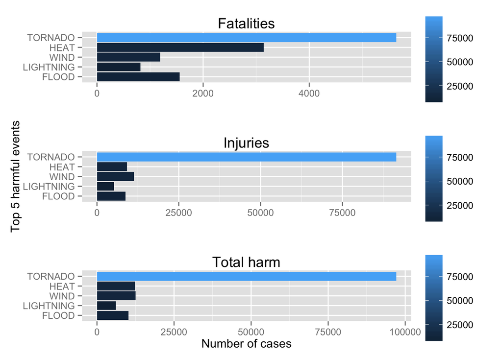

```r
chart.data <- ggplot(head(social, 5), aes(x = evtype))
fat.chart <- chart.data + geom_bar(aes(y = fatalities, fill = total.harm), stat = "identity") + ylab("") + xlab("") + labs(title = "Fatalities") + coord_flip() + theme(legend.title = element_blank())
inj.chart <- chart.data + geom_bar(aes(y = injuries, fill = total.harm), stat = "identity") + ylab("") + xlab("Top 5 harmful events") + labs(title = "Injuries") + coord_flip() + theme(legend.title = element_blank())
harm.chart <- chart.data + geom_bar(aes(y = total.harm, fill = total.harm), stat = "identity") + ylab("Number of cases") + xlab("") + labs(title = "Total harm")  + coord_flip() + theme(legend.title = element_blank())

grid.arrange(fat.chart, inj.chart, harm.chart, nrow = 3)
```

#### Table of the fatalities, injuries and total harm across the US.

```r
kable(social, col.names = c("EVENT TYPE", "FATALITIES", "INJURIES", "TOTAL HARM"))
```

| EVENT TYPE | FATALITIES | INJURIES | TOTAL HARM |
| --- | --- | --- | --- |
| TORNADO | 5636 | 91407 | 97043 |
| WIND | 1191 | 11319 | 12510 |
| HEAT | 3144 | 9228 | 12372 |
| FLOOD | 1560 | 8712 | 10272 |
| LIGHTNING | 817 | 5232 | 6049 |
| STORM | 389 | 3790 | 4179 |
| FIRE | 90 | 1608 | 1698 |
| COLD | 540 | 973 | 1513 |
| HAIL | 45 | 1467 | 1512 |
| HURRICANE | 133 | 1333 | 1466 |
| SNOW | 151 | 1163 | 1314 |
| FOG | 80 | 1076 | 1156 |
| OTHER | 580 | 544 | 1124 |
| BLIZZARD | 101 | 805 | 906 |
| WAVES | 217 | 390 | 607 |
| DUST | 24 | 483 | 507 |
| ICE | 21 | 412 | 433 |
| RAIN | 107 | 308 | 415 |
| AVALANCHE | 225 | 171 | 396 |
| SLUMP | 44 | 55 | 99 |
| DRY | 32 | 28 | 60 |
| DROUGHT | 6 | 19 | 25 |
| TIDE | 11 | 5 | 16 |
| DROWNING | 1 | 0 | 1 |

### Economic impact - total damage

As economic impact the total damage to properties and crops will be analysed. The total damage will be the sum of damages to properties and crops caused by the event type. Thus we’ll try to find out which types of events (as indicated in the EVTYPE variable), across all United States, have the most impact on economy.

```r
economy <- dplyr::select(storm.data, evtype, cropdmg, propdmg) %>%
  dplyr::group_by(evtype) %>%
  dplyr::summarize(cropdmg = sum(cropdmg, na.rm = TRUE),
            propdmg = sum(propdmg, na.rm = TRUE)) %>%
  dplyr::mutate(total.dmg = cropdmg + propdmg) %>%
  dplyr::filter(cropdmg > 0 | cropdmg > 0) %>%
  dplyr::arrange(desc(total.dmg))
```

#### Plot of the top 5 most harmful events across the US.

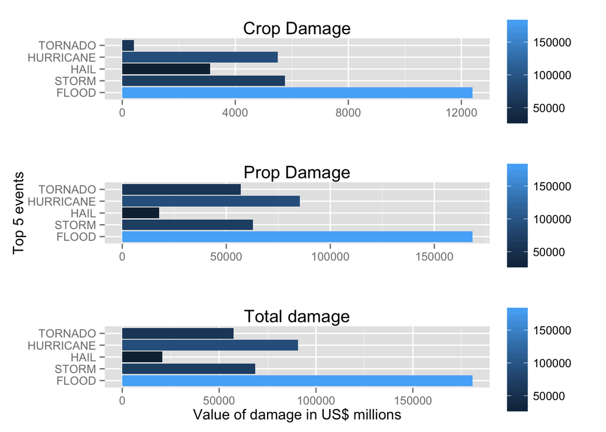

```r
chart.data <- ggplot(head(economy, 5), aes(x = evtype))
crop.chart <- chart.data + geom_bar(aes(y = cropdmg, fill = total.dmg), stat = "identity") + ylab("") + xlab("") + labs(title = "Crop Damage") + coord_flip() + theme(legend.title = element_blank())
prop.chart <- chart.data + geom_bar(aes(y = propdmg, fill = total.dmg), stat = "identity") + ylab("") + xlab("Top 5 events") + labs(title = "Prop Damage") + coord_flip() + theme(legend.title = element_blank())
dmg.chart <- chart.data + geom_bar(aes(y = total.dmg, fill = total.dmg), stat = "identity") + ylab("Value of damage in US$ millions") + xlab("") + labs(title = "Total damage")  + coord_flip() + theme(legend.title = element_blank())

grid.arrange(crop.chart, prop.chart, dmg.chart, nrow = 3)
```

```r
kable(economy, col.names = c("EVENT TYPE", "CROP DAMAGE", "PROP DAMAGE", "TOTAL DAMAGE"))
```

| EVENT TYPE | CROP DAMAGE | PROP DAMAGE | TOTAL DAMAGE |
| --- | --- | --- | --- |
| FLOOD | 12388.59720 | 168280.59444 | 180669.19164 |
| HURRICANE | 5506.11780 | 85256.41001 | 90762.52781 |
| STORM | 5762.66350 | 62880.31521 | 68642.97871 |
| TORNADO | 414.96147 | 57003.31831 | 57418.27978 |
| HAIL | 3114.21287 | 17622.99146 | 20737.20433 |
| WIND | 1970.96913 | 16167.94899 | 18138.91812 |
| DROUGHT | 13972.62178 | 1046.30600 | 15018.92778 |
| FIRE | 403.28163 | 8496.62850 | 8899.91013 |
| TIDE | 0.85000 | 4650.93315 | 4651.78315 |
| RAIN | 948.16280 | 3239.75619 | 4187.91899 |
| COLD | 3325.82655 | 309.54745 | 3635.37400 |
| SNOW | 134.66310 | 1012.68974 | 1147.35284 |
| LIGHTNING | 12.09209 | 935.41943 | 947.51152 |
| HEAT | 904.42350 | 20.12575 | 924.54925 |
| BLIZZARD | 112.06000 | 659.91395 | 771.97395 |
| SLUMP | 20.01700 | 326.83310 | 346.85010 |
| WAVES | 0.02000 | 246.55250 | 246.57250 |
| ICE | 108.00080 | 14.43270 | 122.43350 |
| DUST | 3.60000 | 6.33813 | 9.93813 |
| DRY | 0.01500 | 6.73260 | 6.74760 |
| OTHER | 1.03440 | 2.78010 | 3.81450 |
| GUSTNADO | 0.00155 | 0.10205 | 0.10360 |

## Conclusion

Floods, Tornados, Huricanes and Storms are the key events that government management should focus their efforts. Tornados in special are the most harmful events and are one with the most economic impact. Floods are specially economic harmful.